# Stats 1510 - Assignment Zero

Armin Hatefi

Tuesday, January 18, 2022

In this lab,

- This document will serve as a sample template.
- It is pre-formatted and already contains examples and chunks that demonestarte you how to complete your assignmet or project with *R Markdown*.

Here, I show you how to some additional notes:

For example, If I want to create an ordered list (see above for unordered list), we articulate them as follows:

1- We can insert a URL in R Markdown. Here is the [**D2L Shell URL**](https://online.mun.ca/d2l/loginh/).

2- We can `highlight words` in R Mardown.

3- *Did you notice that this item was written in italic font?*

4- I can easily **bold word(s) in my R Markdown!**

# Exercise 1.11

The population is pregnant and breast-feeding women. The sample consists of the 21 women who returned the surveys.

Only 21/60*100% = 35% of the women who were contacted responded.

# Exercise 3.1

The margin of error for 95% confidence will be about

```r
# You can type directly your mathematical calculations in R Markdown as follows:
```

$$\frac{1}{\sqrt{1033}}=\frac{1}{32.14}=0.031~~~ \text{(that is, $3.1\%$).}$$

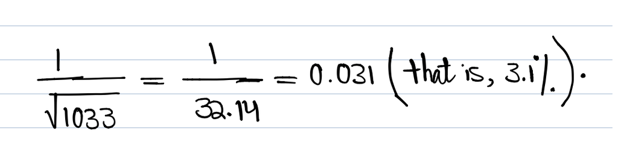

```r
# Or you can add your hand-written calculations as an image in R Markdown as follows:
```

# Exercise 11.21

Stemplot and Histogram. The distribution is roughly symmetric (it appears slightly left skewed if the stems are split), and centered at 46 (a *typical* year). Ruth’s best year was not at all unusual for him; 60 is *not* an outlier.

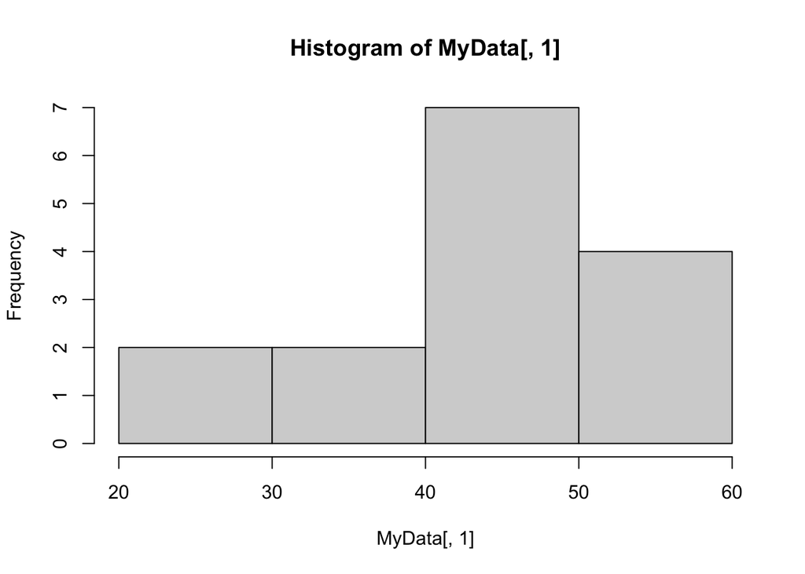

```r
MyData <- read.csv(file= "ex11-21.csv", header = TRUE)
hist(MyData[,1],breaks=5,freq=TRUE)
```

```r
xBar = mean(MyData[,1])
xBar
```

```
## [1] 43.93333
```

```r
M <- median(MyData[,1])
M
```

```
## [1] 46
```

```r
xSD <- sd(MyData[,1])
xSD
```

```
## [1] 11.24701
```

```r
summary(MyData[,1])
```

```
##    Min. 1st Qu.  Median    Mean 3rd Qu.    Max.
##   22.00   38.00   46.00   43.93   51.50   60.00
```

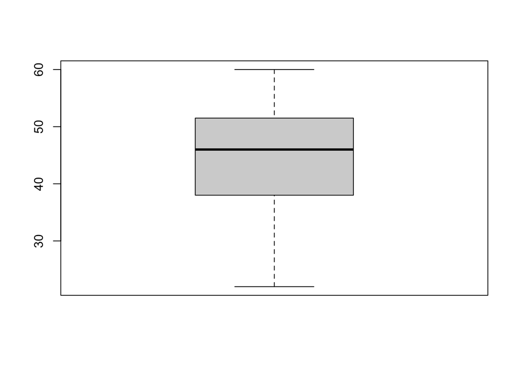

```r
boxplot(MyData[,1])
```

Clearly we see that the median 46 is greater than the mean 43.9333333.

# Additional Resources

- I also recommend to take a look at this R Markdown “Cheatsheet”

(https://www.rstudio.com/wp-content/uploads/2015/02/rmarkdown-cheatsheet.pdf).